Skip to main content

# 266A Final Project

Big question: Can we use dimethyl sulfate (DMS) structure probing techniques to accurately determine pair bases in *in vitro* transcribed human telomerasa RNA (hTR)?

Author

Kimmy Ferry

Published

November 24, 2026

# 1 The project at a glance

**Question.**

Big question: Can we use dimethyl sulfate (DMS) structure probing techniques to accurately determine pair bases in *in vitro* transcribed human telomerasa RNA (hTR)?

**Data.**

Collected from hTR modified through DMS probing. DMS modification induces base mismatch modification during reverse-transcription which is mapped by Illumina short read sequencing.

| File in `data/raw/` | Source (link) | Format | License / terms |
| --- | --- | --- | --- |
| `data/raw/266_seq_data.csv` | Experimental data | CSV |  |

**Folders.**

```
266A_FINAL
├── run-analysis.qmd   <- render this to run everything
├── README.md          <- points here
├── data/raw          <- never edited
├── data/processed   <- written by the pipeline
├── scripts/               <- one script per step
└── output/            <- figures and tables
```

# 2 Before you render (one time only)

1. Open this folder in Positron (*File → Open Folder*).
2. Install the exact package versions:

```r
renv::restore()
```

# 3 Step 1: Import and clean

Data cleaning steps:

```r
library("tidyverse")
library("readr")

seq_data <- read.csv("data/raw/266_seq_data.csv")

str(seq_data)
```

```
'data.frame':   1260 obs. of  7 variables:
 $ sample         : chr  "hTR_DMS_1" "hTR_DMS_1" "hTR_DMS_1" "hTR_DMS_1" ...
 $ probe          : chr  "DMS_plus" "DMS_plus" "DMS_plus" "DMS_plus" ...
 $ nucleotide     : int  1 2 3 4 5 6 7 8 9 10 ...
 $ sequence       : chr  "a" "u" "g" "g" ...
 $ mutations      : int  0 0 0 0 0 0 0 0 0 0 ...
 $ raw_read_depth : int  0 0 4 5 6 8 13 15 29 71 ...
 $ effective_depth: int  0 0 0 0 0 0 0 1 3 22 ...
```

```r
summary(seq_data$mutation[seq_data$sample %in% "hTR_DMS_1" & seq_data$probe %in% "DMS_plus"])
```

```
   Min. 1st Qu.  Median    Mean 3rd Qu.    Max.
    0.0   131.5   680.0  1249.6  1940.5  7688.0
```

```r
summary(seq_data$mutation[seq_data$sample %in% "hTR_DMS_2" & seq_data$probe %in% "DMS_plus"])
```

```
   Min. 1st Qu.  Median    Mean 3rd Qu.    Max.
      0     192     840    1375    1708   21192
```

```r
summary(seq_data$mutation[seq_data$sample %in% "hTR_DMS_1" & seq_data$probe %in% "DMS_minus"])
```

```
   Min. 1st Qu.  Median    Mean 3rd Qu.    Max.
    0.0   354.5   717.0   882.7  1157.5  4289.0
```

```r
summary(seq_data$mutation[seq_data$sample %in% "hTR_DMS_2" & seq_data$probe %in% "DMS_minus"])
```

```
   Min. 1st Qu.  Median    Mean 3rd Qu.    Max.
    0.0   189.0   588.0   847.9  1058.0 13482.0
```

```r
zeros_vals <- seq_data[which(seq_data$raw_read_depth <= 0 | seq_data$effective_depth <= 0), ]   #mutation rate is mutations/read depth so read depths cannot be zero

seq_data$raw_read_depth[seq_data$raw_read_depth <= 0] <- NA    #remove zero values
seq_data$effective_depth[seq_data$effective_depth <= 0] <- NA   #remove zero values
seq_data$raw_read_depth <- as.numeric(seq_data$raw_read_depth)
NA_val <- sum(is.na(seq_data$raw_read_depth), is.na(seq_data$effective_depth))  #check how many NAs are found



if (any(seq_data$raw_read_depth <= 0 | seq_data$effective_depth <= 0, na.rm = TRUE)) stop("zero values must be removed")

str(seq_data)
```

```
'data.frame':   1260 obs. of  7 variables:
 $ sample         : chr  "hTR_DMS_1" "hTR_DMS_1" "hTR_DMS_1" "hTR_DMS_1" ...
 $ probe          : chr  "DMS_plus" "DMS_plus" "DMS_plus" "DMS_plus" ...
 $ nucleotide     : int  1 2 3 4 5 6 7 8 9 10 ...
 $ sequence       : chr  "a" "u" "g" "g" ...
 $ mutations      : int  0 0 0 0 0 0 0 0 0 0 ...
 $ raw_read_depth : num  NA NA 4 5 6 8 13 15 29 71 ...
 $ effective_depth: int  NA NA NA NA NA NA NA 1 3 22 ...
```

```r
message("seq_data is cleaned")

write.csv(seq_data, "data/processed/seq_clean.csv", row.names = FALSE)
seq_clean <- read.csv("data/processed/seq_clean.csv")
dim(seq_clean)
```

```
[1] 1260    7
```

# 4 Step 2: Process data

```r
source("scripts/clean_seq_data.R")
```

```
'data.frame':   1260 obs. of  7 variables:
 $ sample         : chr  "hTR_DMS_1" "hTR_DMS_1" "hTR_DMS_1" "hTR_DMS_1" ...
 $ probe          : chr  "DMS_plus" "DMS_plus" "DMS_plus" "DMS_plus" ...
 $ nucleotide     : int  1 2 3 4 5 6 7 8 9 10 ...
 $ sequence       : chr  "a" "u" "g" "g" ...
 $ mutations      : int  0 0 0 0 0 0 0 0 0 0 ...
 $ raw_read_depth : int  0 0 4 5 6 8 13 15 29 71 ...
 $ effective_depth: int  0 0 0 0 0 0 0 1 3 22 ...
'data.frame':   1260 obs. of  7 variables:
 $ sample         : chr  "hTR_DMS_1" "hTR_DMS_1" "hTR_DMS_1" "hTR_DMS_1" ...
 $ probe          : chr  "DMS_plus" "DMS_plus" "DMS_plus" "DMS_plus" ...
 $ nucleotide     : int  1 2 3 4 5 6 7 8 9 10 ...
 $ sequence       : chr  "a" "u" "g" "g" ...
 $ mutations      : int  0 0 0 0 0 0 0 0 0 0 ...
 $ raw_read_depth : num  NA NA 4 5 6 8 13 15 29 71 ...
 $ effective_depth: int  NA NA NA NA NA NA NA 1 3 22 ...
```

```r
#create two new columns with mutation rates

seq_clean$raw_mut_rate <- seq_clean$mutations / seq_clean$raw_read_depth
seq_clean$effective_mut_rate <- seq_clean$mutations / seq_clean$effective_depth
```

# 5 Step 3: Visualize data

```r
source("scripts/clean_seq_data.R")
```

```
'data.frame':   1260 obs. of  7 variables:
 $ sample         : chr  "hTR_DMS_1" "hTR_DMS_1" "hTR_DMS_1" "hTR_DMS_1" ...
 $ probe          : chr  "DMS_plus" "DMS_plus" "DMS_plus" "DMS_plus" ...
 $ nucleotide     : int  1 2 3 4 5 6 7 8 9 10 ...
 $ sequence       : chr  "a" "u" "g" "g" ...
 $ mutations      : int  0 0 0 0 0 0 0 0 0 0 ...
 $ raw_read_depth : int  0 0 4 5 6 8 13 15 29 71 ...
 $ effective_depth: int  0 0 0 0 0 0 0 1 3 22 ...
'data.frame':   1260 obs. of  7 variables:
 $ sample         : chr  "hTR_DMS_1" "hTR_DMS_1" "hTR_DMS_1" "hTR_DMS_1" ...
 $ probe          : chr  "DMS_plus" "DMS_plus" "DMS_plus" "DMS_plus" ...
 $ nucleotide     : int  1 2 3 4 5 6 7 8 9 10 ...
 $ sequence       : chr  "a" "u" "g" "g" ...
 $ mutations      : int  0 0 0 0 0 0 0 0 0 0 ...
 $ raw_read_depth : num  NA NA 4 5 6 8 13 15 29 71 ...
 $ effective_depth: int  NA NA NA NA NA NA NA 1 3 22 ...
```

```r
source("scripts/mut_rate.R")
```

```
'data.frame':   1260 obs. of  7 variables:
 $ sample         : chr  "hTR_DMS_1" "hTR_DMS_1" "hTR_DMS_1" "hTR_DMS_1" ...
 $ probe          : chr  "DMS_plus" "DMS_plus" "DMS_plus" "DMS_plus" ...
 $ nucleotide     : int  1 2 3 4 5 6 7 8 9 10 ...
 $ sequence       : chr  "a" "u" "g" "g" ...
 $ mutations      : int  0 0 0 0 0 0 0 0 0 0 ...
 $ raw_read_depth : int  0 0 4 5 6 8 13 15 29 71 ...
 $ effective_depth: int  0 0 0 0 0 0 0 1 3 22 ...
'data.frame':   1260 obs. of  7 variables:
 $ sample         : chr  "hTR_DMS_1" "hTR_DMS_1" "hTR_DMS_1" "hTR_DMS_1" ...
 $ probe          : chr  "DMS_plus" "DMS_plus" "DMS_plus" "DMS_plus" ...
 $ nucleotide     : int  1 2 3 4 5 6 7 8 9 10 ...
 $ sequence       : chr  "a" "u" "g" "g" ...
 $ mutations      : int  0 0 0 0 0 0 0 0 0 0 ...
 $ raw_read_depth : num  NA NA 4 5 6 8 13 15 29 71 ...
 $ effective_depth: int  NA NA NA NA NA NA NA 1 3 22 ...
```

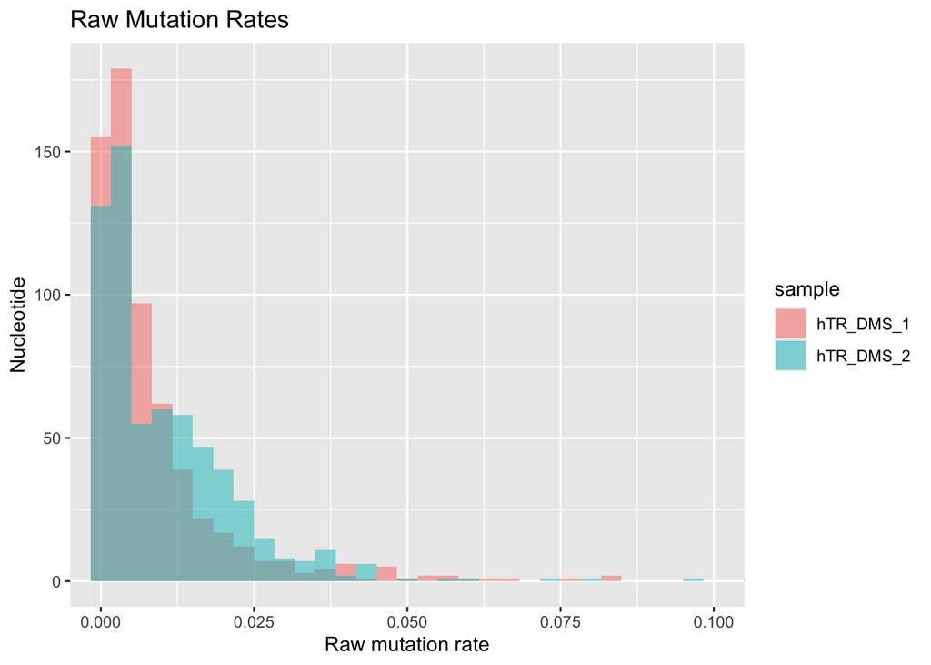

```r
library(ggplot2)

#| label: hist-raw
raw_mut <- ggplot(seq_clean, aes(x = raw_mut_rate, fill = sample)) + geom_histogram(bins = 120, position = "identity", alpha = 0.5) + coord_cartesian(xlim = c(0, 0.1)) + labs(x = "Raw mutation rate", y = "Nucleotide", title = "Raw Mutation Rates")

raw_mut
```

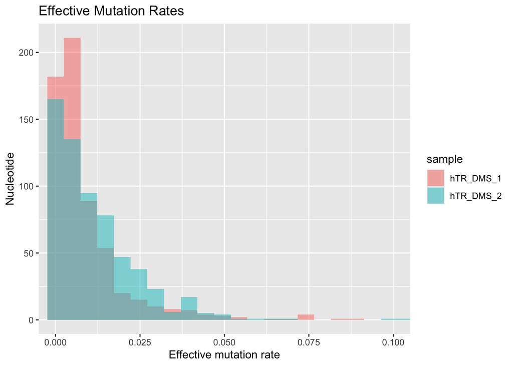

```r
#| label: hist-eff
eff_mut <- ggplot(seq_clean, aes(x = effective_mut_rate, fill = sample)) + geom_histogram(bins = 200, position = "identity", alpha = 0.5) + coord_cartesian(xlim = c(0, 0.1)) + labs(x = "Effective mutation rate", y = "Nucleotide", title = "Effective Mutation Rates")
eff_mut
```

This plot plot shows distribution of the mutation rate calculated from the raw read depth data which is why I chose to plot this as a histogram.

Similarly, I plotted the rates calculated with the effective read depth, which is found by more stringent read filtering, as a histogram to represent the distribution for each nucleotide position.

Linear regression correlations:

```r
source("scripts/clean_seq_data.R")
```

```
'data.frame':   1260 obs. of  7 variables:
 $ sample         : chr  "hTR_DMS_1" "hTR_DMS_1" "hTR_DMS_1" "hTR_DMS_1" ...
 $ probe          : chr  "DMS_plus" "DMS_plus" "DMS_plus" "DMS_plus" ...
 $ nucleotide     : int  1 2 3 4 5 6 7 8 9 10 ...
 $ sequence       : chr  "a" "u" "g" "g" ...
 $ mutations      : int  0 0 0 0 0 0 0 0 0 0 ...
 $ raw_read_depth : int  0 0 4 5 6 8 13 15 29 71 ...
 $ effective_depth: int  0 0 0 0 0 0 0 1 3 22 ...
'data.frame':   1260 obs. of  7 variables:
 $ sample         : chr  "hTR_DMS_1" "hTR_DMS_1" "hTR_DMS_1" "hTR_DMS_1" ...
 $ probe          : chr  "DMS_plus" "DMS_plus" "DMS_plus" "DMS_plus" ...
 $ nucleotide     : int  1 2 3 4 5 6 7 8 9 10 ...
 $ sequence       : chr  "a" "u" "g" "g" ...
 $ mutations      : int  0 0 0 0 0 0 0 0 0 0 ...
 $ raw_read_depth : num  NA NA 4 5 6 8 13 15 29 71 ...
 $ effective_depth: int  NA NA NA NA NA NA NA 1 3 22 ...
```

```r
source("scripts/mut_rate.R")
```

```
'data.frame':   1260 obs. of  7 variables:
 $ sample         : chr  "hTR_DMS_1" "hTR_DMS_1" "hTR_DMS_1" "hTR_DMS_1" ...
 $ probe          : chr  "DMS_plus" "DMS_plus" "DMS_plus" "DMS_plus" ...
 $ nucleotide     : int  1 2 3 4 5 6 7 8 9 10 ...
 $ sequence       : chr  "a" "u" "g" "g" ...
 $ mutations      : int  0 0 0 0 0 0 0 0 0 0 ...
 $ raw_read_depth : int  0 0 4 5 6 8 13 15 29 71 ...
 $ effective_depth: int  0 0 0 0 0 0 0 1 3 22 ...
'data.frame':   1260 obs. of  7 variables:
 $ sample         : chr  "hTR_DMS_1" "hTR_DMS_1" "hTR_DMS_1" "hTR_DMS_1" ...
 $ probe          : chr  "DMS_plus" "DMS_plus" "DMS_plus" "DMS_plus" ...
 $ nucleotide     : int  1 2 3 4 5 6 7 8 9 10 ...
 $ sequence       : chr  "a" "u" "g" "g" ...
 $ mutations      : int  0 0 0 0 0 0 0 0 0 0 ...
 $ raw_read_depth : num  NA NA 4 5 6 8 13 15 29 71 ...
 $ effective_depth: int  NA NA NA NA NA NA NA 1 3 22 ...
```

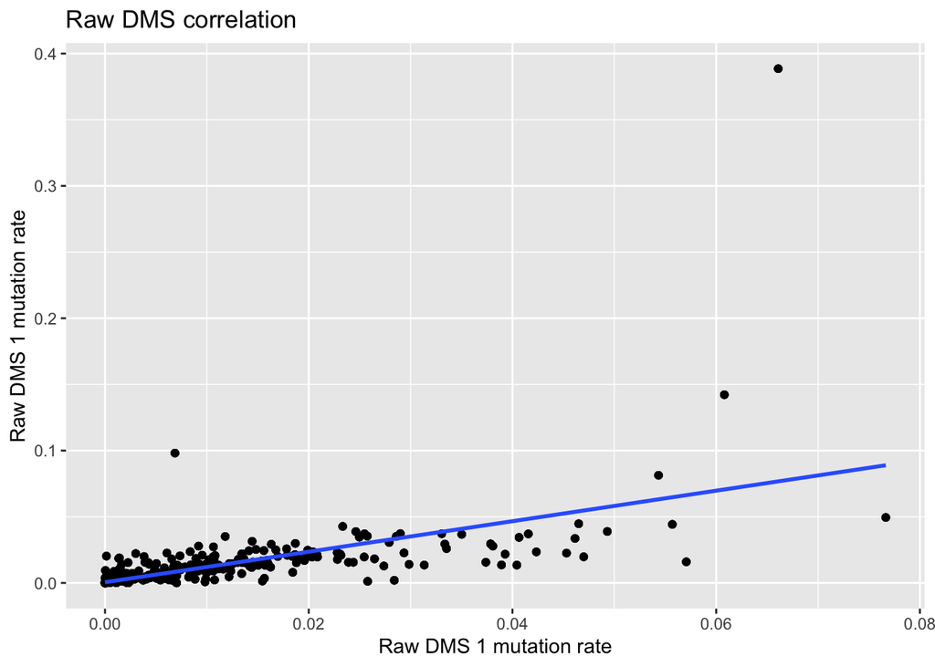

```r
library(ggplot2)

seq_clean$raw_DMS1_plus <- seq_clean$raw_mut_rate[seq_clean$sample %in% "hTR_DMS_1" & seq_clean$probe %in% "DMS_plus"]
seq_clean$raw_DMS2_plus <- seq_clean$raw_mut_rate[seq_clean$sample %in% "hTR_DMS_2" & seq_clean$probe %in% "DMS_plus"]
seq_clean$eff_DMS1_plus <- seq_clean$effective_mut_rate[seq_clean$sample %in% "hTR_DMS_1" & seq_clean$probe %in% "DMS_plus"]
seq_clean$eff_DMS2_plus <- seq_clean$effective_mut_rate[seq_clean$sample %in% "hTR_DMS_2" & seq_clean$probe %in% "DMS_plus"]

#| label: corr-raw
raw_corr_plus_plot <- ggplot(seq_clean, aes(x = raw_DMS1_plus, y = raw_DMS2_plus)) + geom_point() + geom_smooth(method = "lm", se = FALSE) + labs(x = "Raw DMS 1 mutation rate", y = "Raw DMS 1 mutation rate", title = "Raw DMS correlation")

raw_corr_plus_plot
```

```r
raw_plus_corr <- lm(raw_DMS1_plus ~ raw_DMS2_plus, data = seq_clean)
coef(raw_plus_corr)
```

```
  (Intercept) raw_DMS2_plus
  0.006834208   0.295914425
```

```r
summary(raw_plus_corr)
```

```
Call:
lm(formula = raw_DMS1_plus ~ raw_DMS2_plus, data = seq_clean)

Residuals:
      Min        1Q    Median        3Q       Max
-0.055731 -0.006545 -0.003613  0.003433  0.055177

Coefficients:
              Estimate Std. Error t value Pr(>|t|)
(Intercept)   0.006834   0.000333   20.52   <2e-16 ***
raw_DMS2_plus 0.295914   0.011629   25.45   <2e-16 ***
---
Signif. codes:  0 '***' 0.001 '**' 0.01 '*' 0.05 '.' 0.1 ' ' 1

Residual standard error: 0.01055 on 1250 degrees of freedom
  (8 observations deleted due to missingness)
Multiple R-squared:  0.3412,    Adjusted R-squared:  0.3407
F-statistic: 647.5 on 1 and 1250 DF,  p-value: < 2.2e-16
```

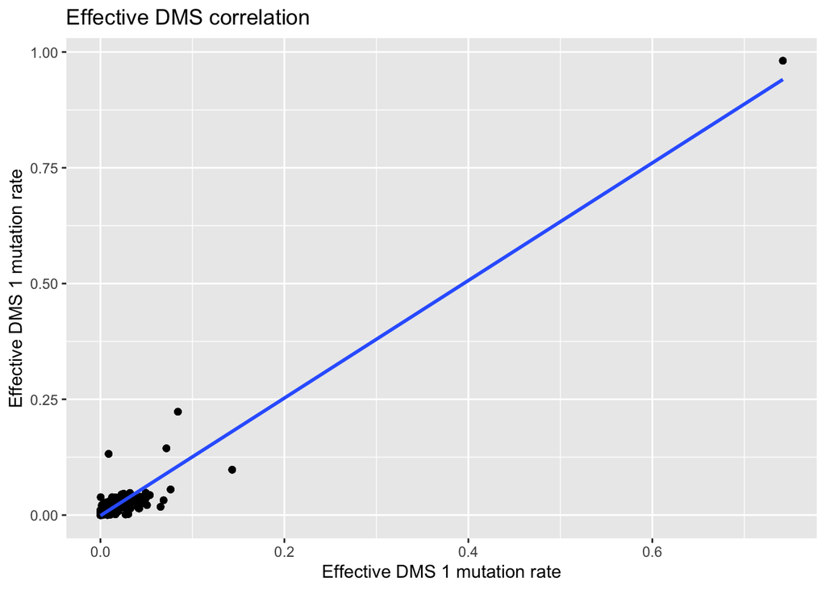

```r
#| label: corr-eff
eff_corr_plus_plot <- ggplot(seq_clean, aes(x = eff_DMS1_plus, y = eff_DMS2_plus)) + geom_point() + geom_smooth(method = "lm", se = FALSE) + labs(x = "Effective DMS 1 mutation rate", y = "Effective DMS 1 mutation rate", title = "Effective DMS correlation")

eff_corr_plus_plot
```